# A força do povo

Por *Alexandre Santos

## Sport Club Corinthians Paulista

[figure not shown]

**Legenda**: escudo atual do Sport Club Corinthians Paulista

Fundado em 1° de Setembro de 1910 por operários, traz na sua fundação a marca impressa na alma de ser um clube de representatividade popular, do povo.  
Time de uma torcida apaixonada, sim, time de uma torcida, apaixonada, louca, ou simplesmente um bando de loucos.

A força desta torcida foi testada em outros momentos históricos como na Invasão Corinthiana

[figure not shown]

**Legenda**: Invasão corinthiana no Maracanã em 76

Esta paixão venceu a seca de titulos de 23 anos, de maneira sofrida em 1977, a seca transformou um time em religião, uma nação.

[figure not shown]

**Legenda**: fim do jejum em 77, gol de Basílio.

Inumeros momentos demosntraram a relevância desta torcida para o rendimento esportivo do corinthians, por exemplo, no 2° título mundial no Japão.

[figure not shown]

**Legenda**: Mundial de clubes do Japão

## Importância da Fiel e do mando de jogo nos resultados esportivos do futebol profissional

É indiscutivel a importância da torcida nas vitórias deste clube, entretanto, uma descrição detalhada dos resultados em campeonatos brasileiros no formato de pontos corridos, ou seja, entre 2003 e 2021, traria uma visão quantitativa do seu impacto.  
Portanto, analisarei a pontuação do Corinthians em campeonatos brasileiros (2003-2021), pontuação em anos de títulos, gols e saldo de gols, traçando um panorama a respeito da importância dos jogos em casa, ou seja, no Estádio do Pacaembu e agora Neo Química Arena.

### Um pouco de dados

##### Tabela 1. Descrição dos resultados do Corinthians no Campeonato Brasileiro (2003-2021).

|  | **Mandante** | **Visitante** |
| --- | --- | --- |
| **Número de Jogos** | 352 | 352 |
| **Número de vitórias** | 193 | 103 |
| **Número de derrotas** | 64 | 140 |
| **Números de empates** | 95 | 109 |
| **Pontos disputados** | 1026 | 1026 |
| **Pontos conquistados** | 674 | 418 |
| **Pontos conquistados(%)** | 65,7 | 40,7 |

Quando visualizamos número pontos, percebemos um aumento no aproveitamento de pontos de 25% quando os jogos são realizados em casa, além disso, apresentando quase o dobro de vitórias jogando em casa.

##### Gráfico 1. Pontuação Corinthians por ano

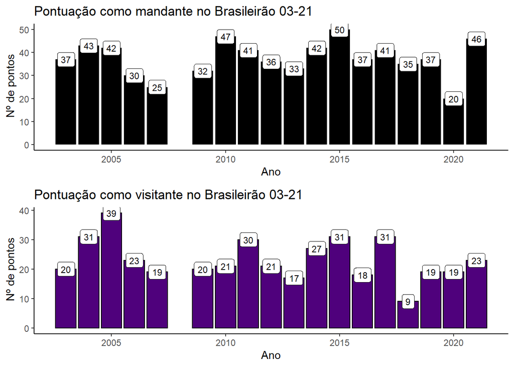

##### Gráfico 2. Porcentagem de pontos do Corinthians

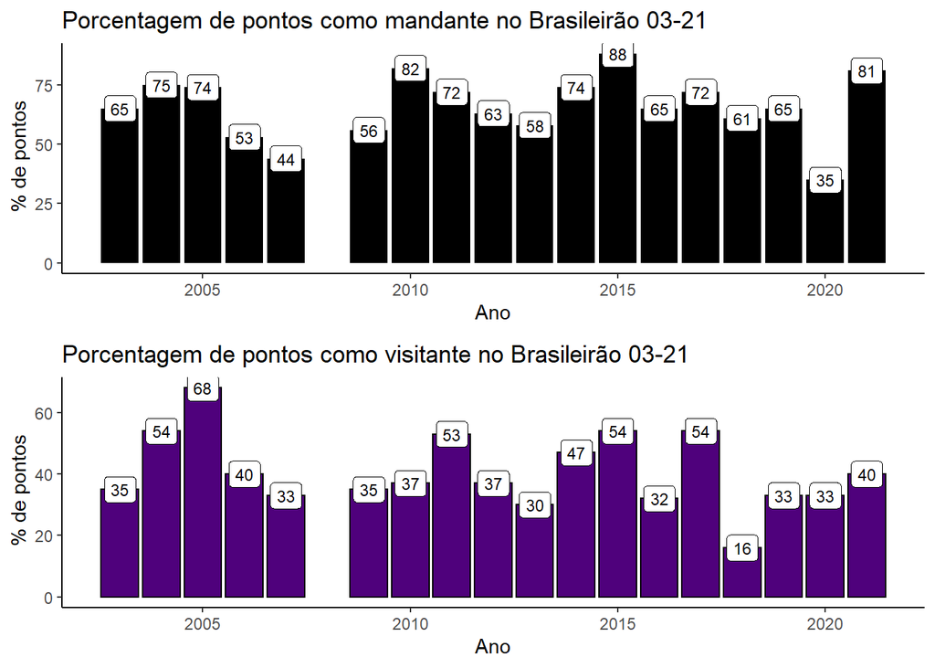

#### Tabela 2. Média de pontos em campeonatos brasileiros (2003-2021)

|  | **Mandante** | **Visitante** |
| --- | --- | --- |
| **Pontos disputados (ano)** | 57 | 57 |
| **Média de pontos conquistados** | 37,44 +- 7,64 | 23,22 +- 7,04 |
| **Média de Pontos conquistados (%)** | 65,72 +- 13,42 | 40,61 +- 12,22 |

#### Tabela 3. Média de pontos nos anos com título no campeonato brasileiro (2005,2011,2015 e 2017)

|  | **Mandante** | **Visitante** |
| --- | --- | --- |
| **Pontos disputados (ano)** | 57 | 57 |
| **Média de pontos conquistados (ano)** | 43,50 +- 4,36 | 32,75 +- 4,19 |
| **Média de pontos conquistados (%)** | 76,50 +- 7,72 | 57,25 +- 7,18 |

Como descrito anteriormente,as médias de pontos conquistados em casa apresentam maiores valores, adicionalmente, em anos de títulos a média sobe ainda mais chegando a apresentar valores aproximadamente 11% maiores em casa.  
Outra possível estimativa é necessidade de aproximadamente 45 pontos em casa e 35 pontos fora para a conquista do campeonato.

#### Figura 3. Gols e saldo de gols como mandante e visitante em campeonatos brasileiros (2003-2021)

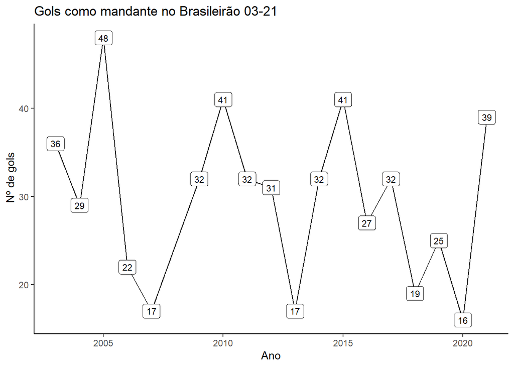

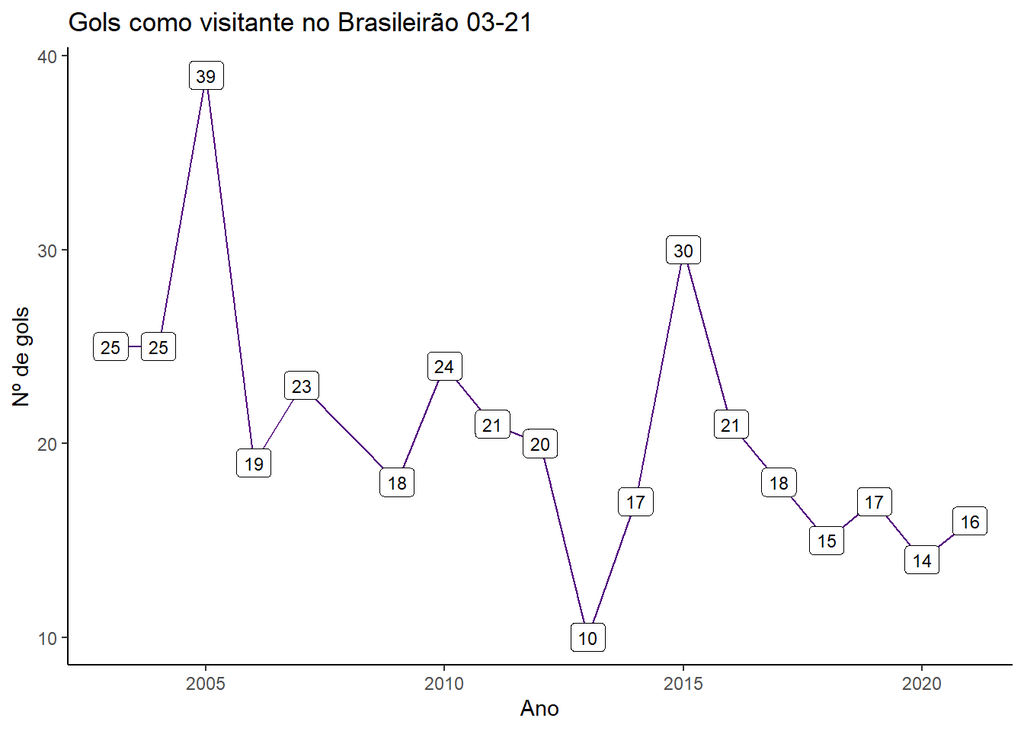

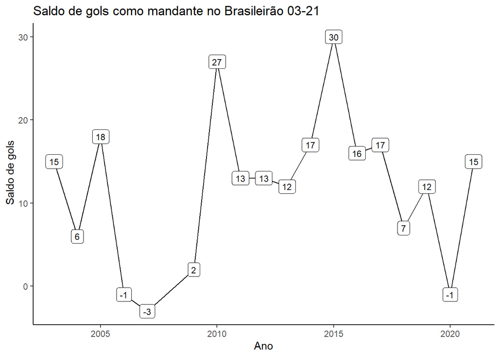

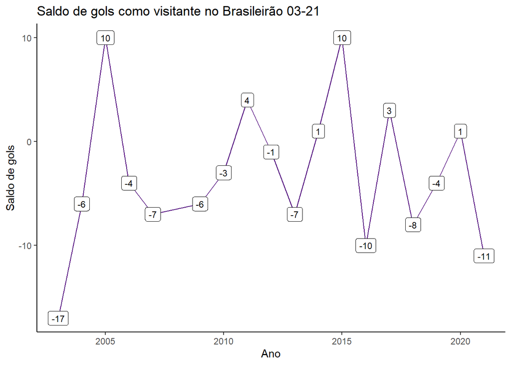

Como visto na pontuação, o Corinthians apresenta maiores valores de gols e saldo de gols (gols corinthians/gols adversário), podemos destacar os saldos negativos tanto em casa como fora em 2006 e 2007, essa piora de saldo de gols em 2006 poderia ter sido encarada como um possível risco para o rebaixamento, a manutenção destes valores negativos produziu o rebaixamento no ano de 2007 que poderia ter sido previsto analisando os dados.

#### Tabela 4. Média de gols e saldo de gols* nos 18 anos de campeonato brasileiro e anos com título

|  | **Mandante** | **Visitante** |
| --- | --- | --- |
| **BR (03-21)** |  |  |
| **Média de gols** | 29,8 +- 9,25 | 20,7 +- 6,57 |
| **Média do saldo de gols** | 11,9 +- 9,06 | -3,1 +- 7,05 |
| **Títulos (05,11,15,17)** |  |  |
| **Média de gols** | 38,2 +- 7,76 | 27,0 +- 9,49 |
| **Média do saldo de gols** | 19,5 +- 7,33 | 6,8 +- 3,77 |

*Saldo de gols = gols do Corinthians/gols adversário

Assim como na análise da pontuação, os gols e saldo são maiores quando o Corinthians é mandante, aumentando ainda mais nos anos de com título.

### O alto rendimento em casa.

Os dados apresentam um aumento do rendimento da equipe quando joga em casa, com aumento do número em gols, saldo de gols, e pontos. Podemos analisar de diversas formas, mas nenhuma exclui a interferência da torcida em seus resultados.  
O ano de 2020 é um possivel modelo que representa a interfência da torcida no saldo de gols e pontos, neste ano obtivemos saldo negativo de gols e pontuação abaixo da média da equipe, sua pior pontuação como mandante, ano este sem torcida devido a pandemia de COVID-19, sendo comparável somente aos dois anos pré série B. Além disso, o número de gols em casa foi o menor da era dos pontos corridos. Mas é claro que podemos questionar a qualidade da equipe, mas em um ciclo de 18 anos esses resultados são no mínimo curiosos.  
Nenhum amante de futebol pode discutir o amor desta torcida, sua força e influência nos resultados.  
Parece que os dados também não questionam sua influência…